# research

Gui Gao, Ishita Khanna, Shu Wang, Chen Wanxin

2022-05-20

# 1 Introduction

With the improvement of people’s living standards, more and more people begin to pay attention to diet. As we all know, a healthy diet can help us maintain a healthy body and figure, and effectively prevent dangerous diseases such as high blood pressure and high blood lipids. In our daily diet, our calorie intake mainly comes from three major nutrients, namely protein, fat and carbohydrates. Studies have shown that the proportion of the three major nutrients in the daily diet plays a very important role in human health. On the other hand, people in different regions have different eating habits due to differences in climate and terrain. In this report, we research the proportion of various food groups in the Australian diet changed over time, and research different food items FAO concentration in Australia and at different period of time. So that we can see whether people are shifting towards being health conscious or are they taking a healthy and balanced diet or not? Besides, we research the differences in diet between the United States and Japan and analyze the changes in the per capita calorie intake and the intake of the three major nutrients in the United States and Japan since 1960, starting from two aspects of eating habits and time trends A comparative analysis of the eating habits and health of the two countries. Rice consumption vs. latitude and region question is also related to our diet.

# 2 Analysis1

```r
# read data
daily_caloric_supply <- read_csv("Data/daily-caloric-supply-derived-from-carbohydrates-protein-and-fat.csv")
dietary_compositions <- read_csv("Data/dietary-compositions-by-commodity-group.csv")
overweight_calories <- read_csv("Data/share-of-adult-men-overweight-or-obese-vs-daily-supply-of-calories.csv")
```

```r
# data wrangling
daily_caloric_supply <- daily_caloric_supply %>%
  rename_all(str_remove, pattern = "\\(FAO.+\\)") %>%
  select(-Code)

dietary_compositions <- dietary_compositions %>%
  rename_all(str_remove, pattern = "\\(FAO.+\\)") %>%
  select(-Code)
```

## 2.1 Research Question1

How the proportion of various food groups in the Australian diet changed over time?

[figure not shown]

Figure 2.1: Kilocalories per Person per Day in Australia

```r
# data figure1
figure1 <- dietary_compositions %>%
  filter(Entity == 'Australia') %>%
  pivot_longer(cols = -c(Entity,Year),
               names_to = 'Variable',
               values_to = 'Value') %>%
  ggplot(aes(x = Year,
             y = Value,
             fill = Variable)) +
  geom_area(color = 'white') +
  scale_fill_viridis_d() +
  labs(y = 'Kilocalories per Person per Day',
       title = 'Kilocalories per Person per Day in Australia') +
  theme_classic() +
  theme(plot.title = element_text(hjust = 0.5),
        legend.position = 'bottom',
        text = element_text(size = 8)) +
  transition_reveal(Year)

figure1
animate(figure1,
        res = 300,
        width = 2000,
        height = 1125,
        renderer = gifski_renderer())
```

```r
anim_save("figure1.gif")
```

## 2.2 Data Explanation

According to Figure2.1, we can see the different colours represent different food groups and the larger the area, the greater the proportion of the Australian diet. It is clear that they prefer cereals and grains, meat, fats and sugary foods to pulses and starchy roots.

## 2.3 Research Question2

How the calories from animal protein varies around the world?

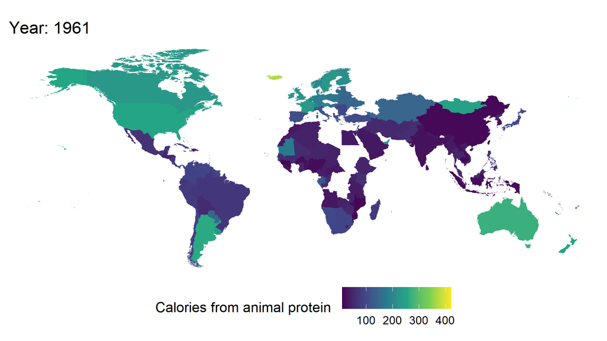

```r
# read world map data
world <- readOGR(dsn = 'World_Countries_(Generalized)/.')
world_shp <- world %>%
  st_as_sf()
world_data <- daily_caloric_supply %>%
  select(Entity, Year, `Calories from animal protein `) %>%
  merge(world_shp,
        by.x = "Entity",
        by.y = "COUNTRY") %>%
  st_as_sf()

# data figure2
figure2 <- world_data %>%
  ggplot(aes(fill = `Calories from animal protein `)) +
  geom_sf(colour = NA) +
  labs(x = 'Longitude',
       y = 'Latitude',
       title = '  Year: {closest_state}') +
  scale_fill_viridis_c(na.value = 'grey') +
  theme_void() +
  theme(legend.position = 'bottom') +
  transition_states(states = Year)
figure2
animate(figure2,
        res = 300,
        width = 2000,
        height = 1125)
```

```r
anim_save('figure2.gif')
```

## 2.4 Data Explanation

To better represent the variation in calories provided by animal protein around the world, I first downloaded data from a world map online, then matched it to the dataset I chose by country name, then filled in the colours according to the calories provided by animal protein to create Figure2.2. The closer the color is to green, the more calories from animal protein, and conversely the closer the color is to blue the less there is. Overall, the amount of calories from animal protein has increased worldwide.

## 2.5 Reference

Observing the Figure2.2 we can find that people living in North America, Oceania, and Europe consume more animal protein to provide calories, simply put, their diet composition prefers meat products, but also from the side to reflect the continued high consumption of livestock products in almost all developed countries Stoll-Kleemann and O’Riordan (2015).

## 2.6 Research Question3

In Australia, Brazil, China, South Africa, United Kingdom and United States, which country has the relatively best linear model of the relationship between overweight or obese and caloric supply since 2000?

```r
# data wrangling
by_entity <- overweight_calories %>%
  rename('caloric_supply' = 'Daily caloric supply (OWID based on UN FAO & historical sources)',
         'Overweight' = 'Overweight or Obese (NCDRisC (2017))') %>%
  select(Entity, Year, caloric_supply, Overweight) %>%
  filter(Entity %in% c("Australia", "China",
                       "United States", "United Kingdom",
                       "South Africa", "Brazil"),
         Year >= 2000) %>%
  drop_na()
```

```r
# linear models
by_entity2 <- by_entity %>%
  group_by(Entity)%>%
  nest()

fit_lm <- function(x){
  lm(Overweight~caloric_supply, data = x)
}
mapped_lm <- map(by_entity$data, fit_lm)
```

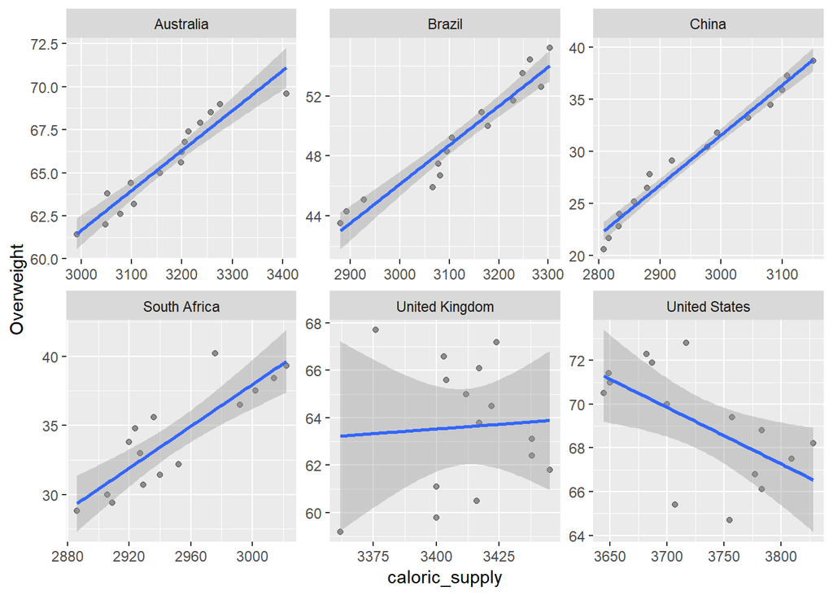

```r
scatter_plot <-
  ggplot(data = by_entity,
       aes(x = caloric_supply,
           y = Overweight)) +
         geom_point(alpha = 0.4) +
  facet_wrap(~Entity, scales = "free") +
  geom_smooth(method = "lm")
scatter_plot
```

```r
entity_model <- by_entity2 %>%
                    mutate(model = map(data, function(x){
                      lm(Overweight~caloric_supply, data = x)
                      })
                      )

entity_model %>%
  mutate(tidy = map(model, tidy))
```

```
# A tibble: 6 x 4
# Groups:   Entity [6]
  Entity         data              model  tidy
  <chr>          <list>            <list> <list>
1 Australia      <tibble [15 x 3]> <lm>   <tibble [2 x 5]>
2 Brazil         <tibble [15 x 3]> <lm>   <tibble [2 x 5]>
3 China          <tibble [15 x 3]> <lm>   <tibble [2 x 5]>
4 South Africa   <tibble [15 x 3]> <lm>   <tibble [2 x 5]>
5 United Kingdom <tibble [15 x 3]> <lm>   <tibble [2 x 5]>
6 United States  <tibble [15 x 3]> <lm>   <tibble [2 x 5]>
```

```r
entity_coefs <- entity_model %>%
                    mutate(tidy = map(model, tidy)) %>%
                    unnest(tidy) %>%
                    select(Entity, term, estimate)
```

```r
tidy_entity_coefs <- entity_coefs %>%
                          pivot_wider(id_cols = c(Entity),
                                      names_from =  term,
                                      values_from = estimate) %>%
                          rename(Intercept = `(Intercept)`,
                                 Slope = caloric_supply)
```

```r
entity_glance <- entity_model %>%
  mutate(glance = map(model, glance)) %>%
  unnest(glance) %>%
  select(Entity, r.squared, AIC, BIC)
```

```r
Table1 = entity_glance
knitr::kable(Table1, booktabs = TRUE, "html",
             caption = "Goodness_of_fit_measures") %>%
  kable_styling(bootstrap_options = c("striped", "hover"))
```

Table 2.1: Goodness_of_fit_measures

| Entity | r.squared | AIC | BIC |
| --- | --- | --- | --- |
| Australia | 0.9079612 | 40.73470 | 42.85885 |
| Brazil | 0.9232400 | 48.68766 | 50.81181 |
| China | 0.9727043 | 46.42461 | 48.54876 |
| South Africa | 0.7375348 | 66.86584 | 68.98999 |
| United Kingdom | 0.0040535 | 77.89588 | 80.02003 |
| United States | 0.3628869 | 69.38632 | 71.51047 |

## 2.7 Data Explanation

The scatter plot shows that the Chinese fitted linear model is the best, while, according to Table2.1, we can find that Chinese linear model has a maximum r.squared value around 0.97 and there are relatively small AIC and BIC values of around 46.42 and 48.55 respectively. Therefore, we can find that Chinese people’s overweight or obese are more affected by calorie intake.

## 2.8 Reference

R-squared is the percentage of outcome variable variation explained by the model, and describes how close the data are to the fitted regression. In general, the higher the R-squared value, the better the model fits. AIC and BIC both aim at achieving a compromise between model goodness of fit and model complexity. The preferred models are those with minimum AIC/BIC (Yang and Berdine (2015)).

# 3 Analysis2

```r
# reading csv file
dietary_csv <- read.csv("Data/dietary-composition-by-country.csv")
```

## 3.1 Research Question1

How much FAO i.e. Fats Animal Oil is in Vegetable Oil in Australia that is consumed by people in different year?

```r
# filter the data
country_vege_oils <- dietary_csv %>%
  filter(Entity == "Australia")
# selecting particular columns
selection <- country_vege_oils %>% select(Year, Vegetable.Oils..FAO..2017..)
# arranging in descending order based on Vegetable oil FAO
arrange(selection ,desc(Vegetable.Oils..FAO..2017..))
```

```
   Year Vegetable.Oils..FAO..2017..
1  2012                         569
2  2013                         550
3  2010                         547
4  2011                         530
5  2004                         524
6  2009                         522
7  2005                         516
8  2006                         508
9  2007                         488
10 2001                         479
11 2008                         479
12 1999                         459
13 2002                         450
14 2000                         441
```

[output cut: 39 more lines]

## 3.2 Research Question2

Comparing the FAO in maize, rice and wheat over the years in single figure to see that they all decreased, increased or differs?

```r
# plotting Maize FAO on different years
maize_plot <- ggplot(country_vege_oils, aes(x = Year, y = Maize..FAO..2017..)) +
  geom_line()
```

```r
# plotting Rice FAO on different years
rice_plot <- ggplot(country_vege_oils, aes(x = Year, y = Rice..FAO..2017..)) +
  geom_line()
```

```r
# plotting Wheat FAO on different years
wheat_plot <- ggplot(country_vege_oils, aes(x = Year, y = Wheat..FAO..2017..)) +
  geom_line()
```

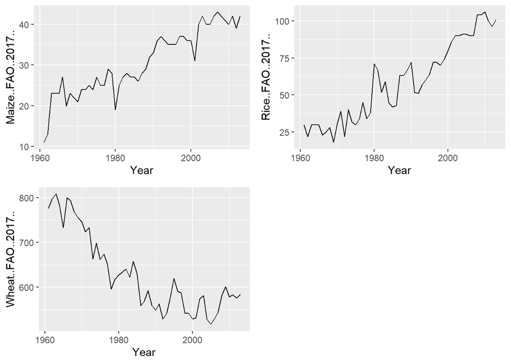

```r
# joining three plots as one figure
ggarrange(maize_plot, rice_plot, wheat_plot)
```

## 3.3 Research Question3

Distribution of FAO in Animal Fat and Vegetable Oil against the averages and skewness.

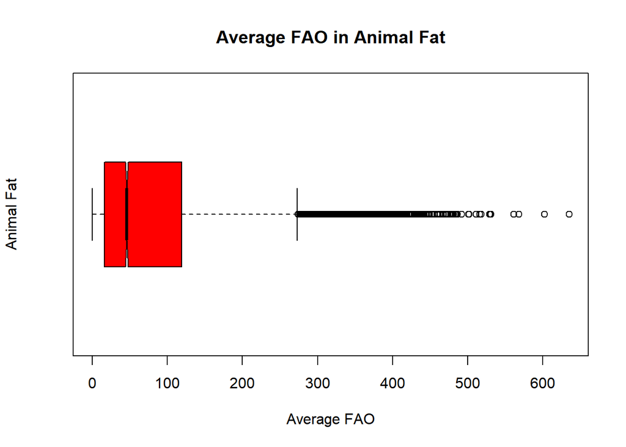

```r
b <- boxplot(dietary_csv$Animal.fats..FAO..2017..,
        main = "Average FAO in Animal Fat",
        xlab = "Average FAO",
        ylab = "Animal Fat",
        col = "red",
        horizontal = TRUE,
        notch = TRUE)
```

```r
b$stats
```

```
     [,1]
[1,]    0
[2,]   16
[3,]   46
[4,]  119
[5,]  273
```

## 3.4 Research Question4

Finding the relation between two variables i.e. Year and FAO in Animal Fat.

```r
dietary_lm <- lm(Year ~ Animal.fats..FAO..2017..,
              data = dietary_csv)
summary(dietary_lm)
```

```
Call:
lm(formula = Year ~ Animal.fats..FAO..2017.., data = dietary_csv)

Residuals:
     Min       1Q   Median       3Q      Max
-27.2921 -13.1134   0.1706  13.1531  30.0798

Coefficients:
                           Estimate Std. Error  t value Pr(>|t|)
(Intercept)               1.988e+03  2.144e-01 9273.059  < 2e-16 ***
Animal.fats..FAO..2017.. -1.276e-02  1.702e-03   -7.498 7.08e-14 ***
---
Signif. codes:  0 '***' 0.001 '**' 0.01 '*' 0.05 '.' 0.1 ' ' 1

Residual standard error: 15.28 on 8979 degrees of freedom
Multiple R-squared:  0.006223,  Adjusted R-squared:  0.006112
F-statistic: 56.22 on 1 and 8979 DF,  p-value: 7.078e-14
```

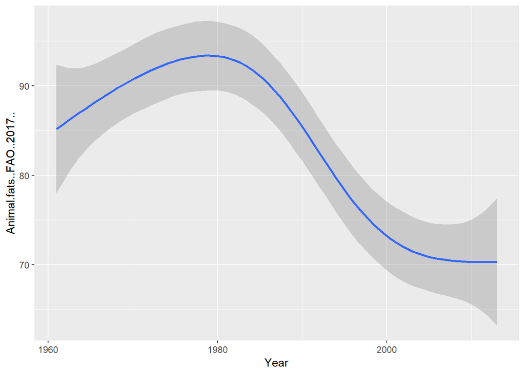

```r
ggplot(dietary_lm) +
  geom_smooth(aes(x=Year, y=Animal.fats..FAO..2017..))
```

## 3.5 Conclusion:

- Maize and Rice FAO is higher in later years but the wheat growth becomes less in later years in Australia.
- Same as maize and rice, Vegetable FAO is growing in later years in Australia.
- There is no particular relation between year and Animal Fat because of different countries but it says that animal fat increases with the increase in year but gets low as well in some countries. So its fluctuating.

# 4 Analysis3

```r
data <- read.csv("Data/daily-caloric-supply-derived-from-carbohydrates-protein-and-fat.csv")

mydata <- data %>% filter(Entity %in% c("United States","Japan"))
```

```r
pct_miss(mydata) #0 missingness in the UK and Iceland data
pct_miss_case(mydata)
pct_miss_var(mydata)
```

```r
mydata <- mydata %>%
  mutate(total_Cal = Calories.from.animal.protein..FAO..2017..
         +Calories.from.plant.protein..FAO..2017..
         +Calories.from.fat..FAO..2017..
         +Calories.from.carbohydrates..FAO..2017..,
         Protein_Cal=Calories.from.animal.protein..FAO..2017..
         +Calories.from.plant.protein..FAO..2017..,
         `Protein(%)`=percent((
           Calories.from.animal.protein..FAO..2017..
           +Calories.from.plant.protein..FAO..2017..)/total_Cal,
           accuracy = 4),
         `Fat(%)`=percent(
           Calories.from.fat..FAO..2017../total_Cal
           ,accuracy = 4),
         `Carbohydrates(%)`=percent(
           Calories.from.carbohydrates..FAO..2017../total_Cal,
           accuracy = 4))%>%
  rename(Fat_Cal=Calories.from.fat..FAO..2017..,
         Carbohydrates_Cal=Calories.from.carbohydrates..FAO..2017..,
         Animal_Protein_Cal=Calories.from.animal.protein..FAO..2017..,
         Plant_Protein_Cal=Calories.from.plant.protein..FAO..2017..)
mydata=mydata%>%
  filter(Year<=2010)%>%
  filter(Year>=1961)

US_Data <- mydata %>% filter(Entity =="United States")

Japan_Data <- mydata %>% filter(Entity =="Japan")

mydata <- US_Data %>% rbind(Japan_Data)

mydata_long <- mydata %>%
  pivot_longer(cols=c(total_Cal,Protein_Cal, Fat_Cal,Carbohydrates_Cal ),
               names_to = "impact_variable", values_to = "measure")
```

## 4.1 Research Question1

What is the difference in the proportions of total Calories and the three major nutrients (protein, fat, carbohydrate) from 1970 in the American and Japanese diets?

```r
mydata %>%
  pivot_wider(id_cols = c(Year),
              names_from = Entity,
              values_from = c(total_Cal)) %>%
  filter(Year>=1970)%>%
  arrange(desc(Year)) %>%
  knitr::kable(caption = "Proportions of the Nutrients Comparision")
```

Table 4.1: Proportions of the Nutrients Comparision

| Year | United States | Japan |
| --- | --- | --- |
| 2010 | 3650 | 2685 |
| 2009 | 3645 | 2675 |
| 2008 | 3700 | 2734 |
| 2007 | 3757 | 2817 |
| 2006 | 3783 | 2778 |
| 2005 | 3828 | 2829 |
| 2004 | 3809 | 2842 |
| 2003 | 3777 | 2842 |
| 2002 | 3783 | 2853 |
| 2001 | 3707 | 2889 |
| 2000 | 3755 | 2899 |
| 1999 | 3673 | 2897 |
| 1998 | 3658 | 2895 |
| 1997 | 3648 | 2938 |
| 1996 | 3587 | 2963 |
| 1995 | 3580 | 2920 |
| 1994 | 3665 | 2932 |
| 1993 | 3605 | 2926 |
| 1992 | 3559 | 2943 |
| 1991 | 3522 | 2934 |
| 1990 | 3493 | 2948 |
| 1989 | 3433 | 2969 |
| 1988 | 3458 | 2941 |
| 1987 | 3450 | 2895 |
| 1986 | 3352 | 2874 |
| 1985 | 3380 | 2861 |
| 1984 | 3275 | 2827 |
| 1983 | 3230 | 2829 |
| 1982 | 3191 | 2813 |
| 1981 | 3218 | 2750 |
| 1980 | 3178 | 2798 |
| 1979 | 3214 | 2807 |
| 1978 | 3155 | 2790 |
| 1977 | 3135 | 2774 |
| 1976 | 3163 | 2751 |
| 1975 | 3033 | 2716 |
| 1974 | 3031 | 2742 |
| 1973 | 3040 | 2772 |
| 1972 | 3062 | 2781 |
| 1971 | 3052 | 2728 |
| 1970 | 3029 | 2737 |

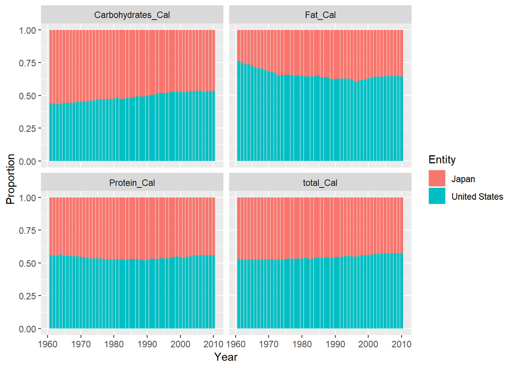

## 4.2 Data Explanation

The figure and table show that from 1961 to 2010, the share of per capita calorie intake in the United States and Japan did not change much, with the United States consistently having slightly higher calorie intake than Japan. From the perspective of the proportion of the three major nutrients of protein, fat and carbohydrates, the intake of fat in the American people’s diet is much higher than that of the Japanese, and the intake of carbohydrates in the daily diet of the Japanese is higher than that of the United States. people. For protein intake, Americans and Japanese intakes are not much different.

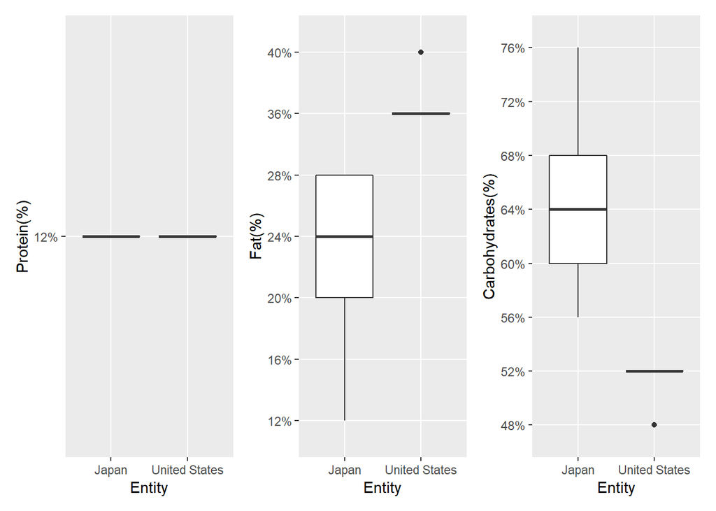

Figure 4.1: Distribution of Protein,Fat,Carbohydrates

## 4.3 Data Explanation

Figure4.1 shows that in terms of diet, the difference in the proportion of protein calories consumed in Japan and the United States is not large, and the values are both around 12%. The proportion of fat and carbohydrates in the calorie intake in Japan and the United States is quite different. The proportion of fat in the Japanese diet is mostly between 20% and 28%, while the proportion of fat in the American diet is between 36% and 38%. between. Carbohydrates, on the other hand, are mostly between 60% and 68% carbohydrates in the Japanese diet, compared to 50% to 52% in the American diet.

## 4.4 Research Question2

What is the difference between the time trends of TotalCalories and Calories of Protein, Fat, Carbohydrates in the two countries?

**Table analysis of both countries**

```r
summary_US <- US_Data %>%
  dplyr::select(total_Cal,Protein_Cal,Fat_Cal,Carbohydrates_Cal) %>%
  summary() %>%
  knitr::kable(caption = "Calories Intake of United States") %>%
         kable_styling(latex_options = "hold_position")

summary_US
```

Table 4.2: Calories Intake of United States

|  | total_Cal | Protein_Cal | Fat_Cal | Carbohydrates_Cal |
| --- | --- | --- | --- | --- |
|  | Min. :2858 | Min. :378.3 | Min. : 982.2 | Min. :1481 |
|  | 1st Qu.:3043 | 1st Qu.:396.0 | 1st Qu.:1077.5 | 1st Qu.:1578 |
|  | Median :3366 | Median :419.8 | Median :1237.6 | Median :1680 |
|  | Mean :3354 | Mean :420.8 | Mean :1221.4 | Mean :1711 |
|  | 3rd Qu.:3650 | 3rd Qu.:448.5 | 3rd Qu.:1303.3 | 3rd Qu.:1863 |
|  | Max. :3828 | Max. :461.9 | Max. :1484.9 | Max. :1941 |

```r
summary_Japan <- Japan_Data %>%
  dplyr::select(total_Cal,Protein_Cal,Fat_Cal,Carbohydrates_Cal) %>%
  summary() %>%
  knitr::kable(caption = "Calories Intake of Japan") %>%
         kable_styling(latex_options = "hold_position")

summary_Japan
```

Table 4.3: Calories Intake of Japan

|  | total_Cal | Protein_Cal | Fat_Cal | Carbohydrates_Cal |
| --- | --- | --- | --- | --- |
|  | Min. :2525 | Min. :296.8 | Min. :310.4 | Min. :1547 |
|  | 1st Qu.:2730 | 1st Qu.:339.9 | 1st Qu.:558.4 | 1st Qu.:1727 |
|  | Median :2810 | Median :359.5 | Median :694.9 | Median :1800 |
|  | Mean :2800 | Mean :357.2 | Mean :652.0 | Mean :1790 |
|  | 3rd Qu.:2895 | 3rd Qu.:380.6 | 3rd Qu.:791.8 | 3rd Qu.:1860 |
|  | Max. :2969 | Max. :392.9 | Max. :815.5 | Max. :1962 |

## 4.5 Data Explanation

It can be seen from Table4.2, that the mean Calories of United States is 3354 kcal while Table4.3 shows Japan’s mean Calories is 2800.In addition, we can observe that the average carbohydrate intake of the Japanese and American diets is almost the same in terms of the average calorie intake of the three nutrients, but the fat intake of the American diet is significantly higher than that of the Japanese diet.

[figure not shown]

```r
plot_Calories_Intake <- mydata%>%
  ggplot(section2_chile_canada, mapping =  aes(
    x = Year,
    y = Protein_Cal,
    color = Entity)) +
  geom_line() +
  theme_bw() +
  xlab("Year") +
  ylab("Total Calories Intake") +
  ggtitle("Calories Intake of over the years")
plot_Calories_Intake
```

## 4.6 Data Explanation

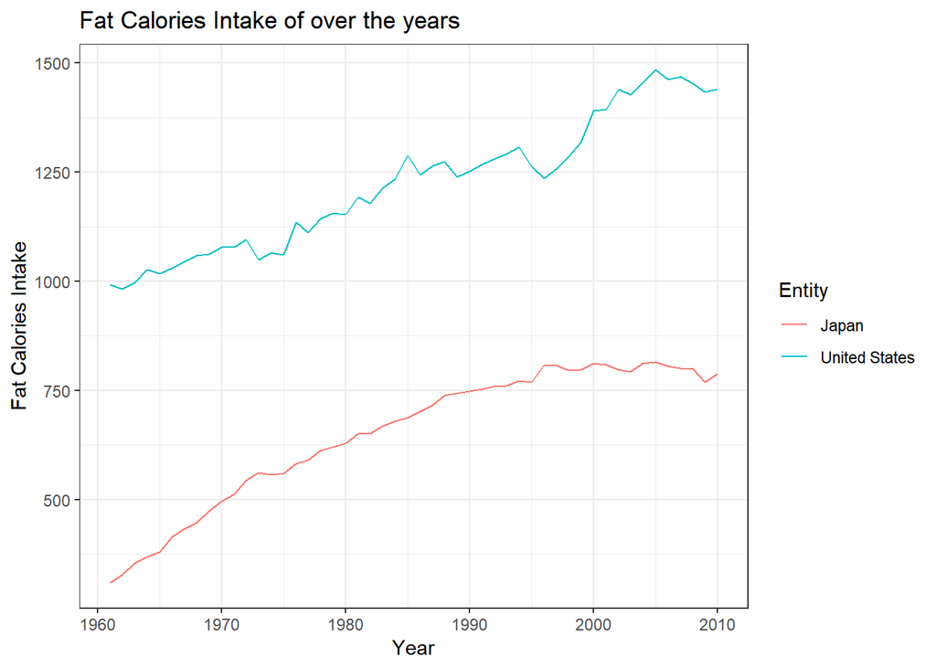

Figure 4.3: Fat Calories Intake of over the years

```r
plot_Fat_Calories_Intake <- mydata%>%
  ggplot(section2_chile_canada, mapping =  aes(
    x = Year,
    y = Fat_Cal,
    color = Entity)) +
  geom_line() +
  theme_bw() +
  xlab("Year") +
  ylab("Fat Calories Intake") +
  ggtitle("Fat Calories Intake of over the years")
plot_Fat_Calories_Intake
```

## 4.7 Data Explanation

# 5 Analysis4

## 5.1 Research Question

Rice consumption vs. latitude and region, 2015

```r
# Data
Assignment4_data <- read_csv("Data/rice-consumption-vs-latitude.csv")
data_tidy <- Assignment4_data %>%
  filter(Year == 2015)%>%
  rename(`Rice consumption(kg/capita/yr)` = `Rice (Milled Equivalent) - Food supply quantity (kg/capita/yr)`) %>%
  rename(Latitude = `Latitude - lp_lat_abst`)

data_tidy <- data_tidy %>% drop_na(`Rice consumption(kg/capita/yr)`) %>% drop_na(Latitude)
```

```r
knitr::kable(
  head(arrange(data_tidy,desc(`Rice consumption(kg/capita/yr)`)),10), caption = 'Top 10 countries with the highest annual per capita consumption of rice in 2015',
  booktabs = TRUE,digits = 2
) %>%
kable_styling(latex_options = c("striped", "hold_position"))
```

Table 5.1: Top 10 countries with the highest annual per capita consumption of rice in 2015

| Entity | Code | Year | Rice consumption(kg/capita/yr) | Latitude | Continent |
| --- | --- | --- | --- | --- | --- |
| Bangladesh | BGD | 2015 | 265.55 | 0.27 | Asia |
| Laos | LAO | 2015 | 255.64 | 0.20 | Asia |
| Cambodia | KHM | 2015 | 239.70 | 0.14 | Asia |
| Vietnam | VNM | 2015 | 218.73 | 0.18 | Asia |
| Indonesia | IDN | 2015 | 211.79 | 0.06 | Asia |
| Myanmar | MMR | 2015 | 184.80 | 0.24 | Asia |
| Sierra Leone | SLE | 2015 | 184.36 | 0.09 | Africa |
| Thailand | THA | 2015 | 176.85 | 0.17 | Asia |
| Philippines | PHL | 2015 | 170.10 | 0.14 | Asia |
| Sri Lanka | LKA | 2015 | 163.80 | 0.08 | Asia |

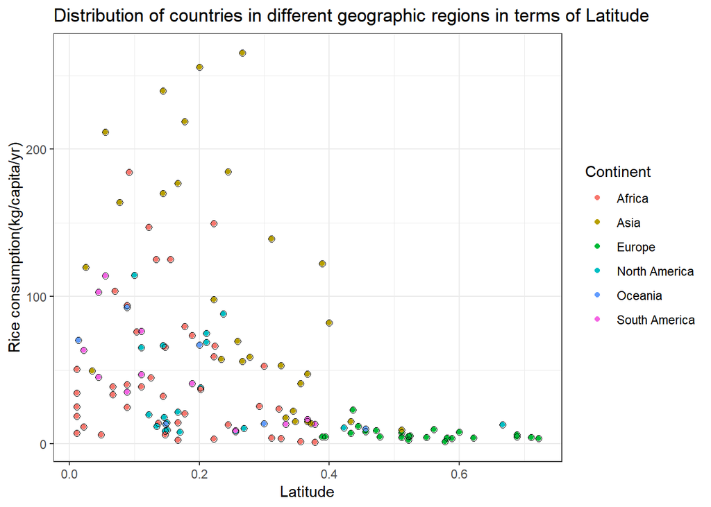

```r
ggplot(data = data_tidy,
aes(x = Latitude,
    y = `Rice consumption(kg/capita/yr)`)) +
 geom_point(aes(colour = Continent)) +
 geom_point(data = data_tidy,
 size = 2,
 shape = 1)+
  theme_bw()+
  ggtitle("Distribution of countries in different geographic regions in terms of Latitude")
```

# 6 Conclusion

According to the Australian government’s dietary guidelines, these unhealthy diets have led to many Australian adults and about a quarter of children being overweight or obese, so it’s time to make changes for the sake of our health Grech, Rangan, and Allman-Farinelli (2018).

All in all, with the development of society and the progress of economy, how to maintain a healthy eating habit has become an increasingly important issue Unger et al. (1992). In addition to paying attention to the total calorie intake of the diet, people also need to pay attention to the energy supply ratio of the three major nutrients, protein, fat and carbohydrates. Reasonable arrangement of the proportion of nutrients can help us maintain a healthier body and prolong our energy consumption. longevity and reduce the incidence of disease Lands et al. (1990).

# Reference

Grech, Amanda, Anna Rangan, and Margaret Allman-Farinelli. 2018. “Macronutrient Composition of the Australian Population’s Diet; Trends from Three National Nutrition Surveys 1983, 1995 and 2012.” *Nutrients* 10 (8): 1045.

Lands, W. E., T. Hamazaki, K. Yamazaki, H. Okuyama, K. Sakai, Y. Goto, and V. S. Hubbard. 1990. “Changing Dietary Patterns.” *American Journal of Clinical Nutrition* 51 (6): 991–93.

Stoll-Kleemann, Susanne, and Tim O’Riordan. 2015. “The Sustainability Challenges of Our Meat and Dairy Diets.” *Environment: Science and Policy for Sustainable Development* 57 (3): 34–48.

Unger, R., M. Dekleermaeker, S. S. Gidding, and K. K. Christoffel. 1992. “Calories Count. Improved Weight Gain with Dietary Intervention in Congenital Heart Disease.” *American Journal of Diseases of Children* 146 (9): 1078.

Yang, Shengping, and Gilbert Berdine. 2015. “Model Selection and Model over-Fitting.” *The Southwest Respiratory and Critical Care Chronicles* 3 (12): 52–55.